# EWS in measles data

2019-01-22

I use the `spaero::get_stats()` function to calculate EWS over a moving window for the measles case incidence data from four cities in Niger. I use a bandwidth of 35 weeks, resulting in a 70 week window. All EWS are calculated with `backward_only = TRUE` so that EWS are only calculated based on data in the past.

```r
# Load packages -----------------------------------------------------------
library(tidyverse)
library(spaero)
# Load data ---------------------------------------------------------------
fname <- "../../data/clean-data/weekly-measles-incidence-niger-cities-clean.RDS"
measles_data <- readRDS(fname) %>%
  filter(year > 1994)  # drop first NA year, only used for modeling
# Calculate EWS -----------------------------------------------------------
all_stats <- tibble()  # empty tibble for storage
for(do_region in unique(measles_data$region)){

  cases <- measles_data %>%
    filter(region == do_region) %>%
    pull(cases)

  city_stats <- spaero::get_stats(
    x = cases,
    center_trend = "local_constant",
    center_kernel = "uniform",
    center_bandwidth = 35,
    stat_trend = "local_constant",
    stat_kernel = "uniform",
    stat_bandwidth = 35,
    lag = 1,
    backward_only = TRUE
  )$stats

  city_stats_tb <- as_tibble(city_stats) %>%
    mutate(
      time_iter = 1:n(),
      date = unique(measles_data$date)
    ) %>%
    gather(key = ews, value = value, -time_iter, -date) %>%
    mutate(region = do_region)

  all_stats <- bind_rows(all_stats, city_stats_tb)
}
```

Define a function to plot the EWS and the observations.

```r
plot_it <- function(dates, cases, ews, lab, title){
  par(mar = c(5,5,2,5))
  plot(dates, cases, type = "l", main = title)
  par(new = T)
  plot(dates, ews, type = "l", col = "red", axes=F, xlab=NA, ylab=NA)
  axis(side = 4)
  mtext(side = 4, line = 3, lab, cex = 0.7)
}
```

### Agadez

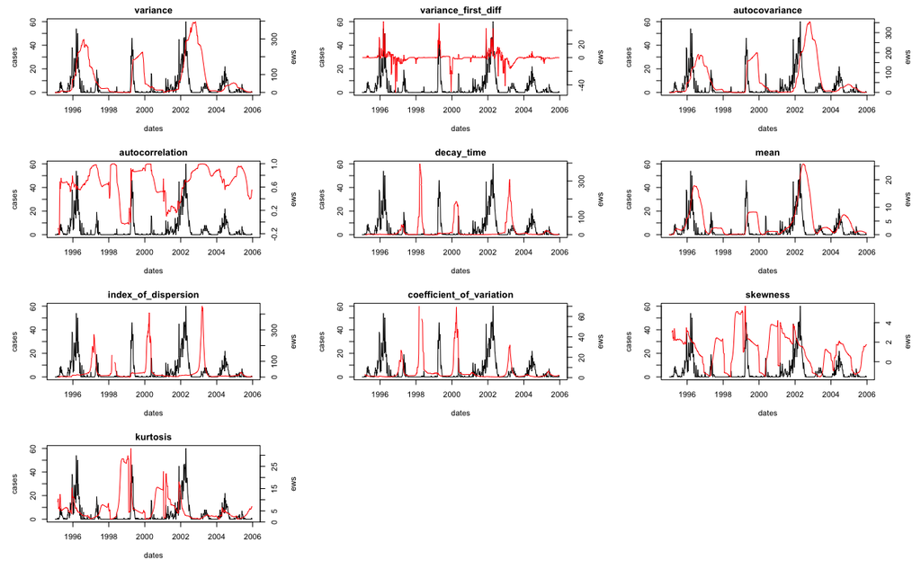

```r
do_region <- "Agadez (City)"
dates <- unique(measles_data$date)
par(mfrow = c(4,3))
for(do_ews in unique(all_stats$ews)){
  cases <- filter(measles_data, region == do_region) %>% pull(cases)
  ews <- filter(all_stats, region == do_region & ews == do_ews) %>% pull(value)
  plot_it(dates, cases, ews, lab = "ews", title = do_ews)
}
```

### Maradi

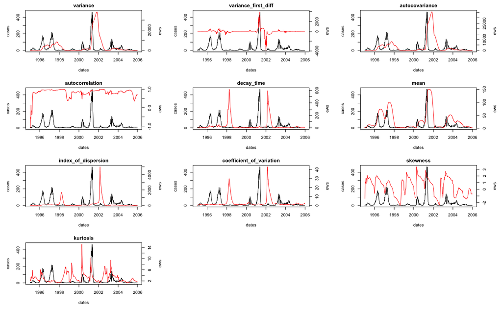

```r
do_region <- "Maradi (City)"
dates <- unique(measles_data$date)
par(mfrow = c(4,3))
for(do_ews in unique(all_stats$ews)){
  cases <- filter(measles_data, region == do_region) %>% pull(cases)
  ews <- filter(all_stats, region == do_region & ews == do_ews) %>% pull(value)
  plot_it(dates, cases, ews, lab = "ews", title = do_ews)
}
```

### Niamey

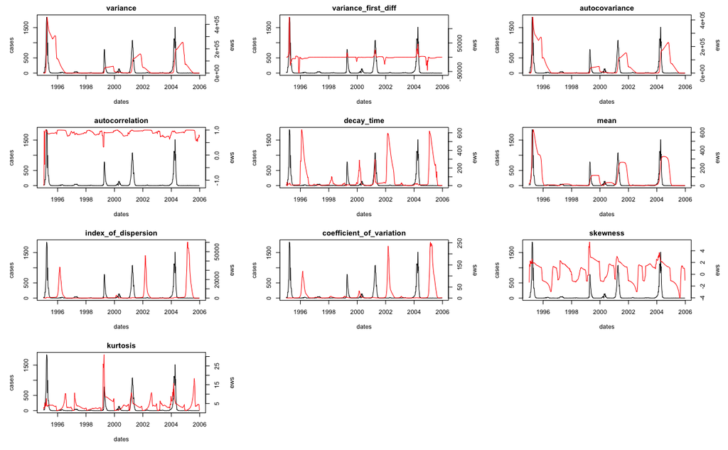

```r
do_region <- "Niamey (City)"
dates <- unique(measles_data$date)
par(mfrow = c(4,3))
for(do_ews in unique(all_stats$ews)){
  cases <- filter(measles_data, region == do_region) %>% pull(cases)
  ews <- filter(all_stats, region == do_region & ews == do_ews) %>% pull(value)
  plot_it(dates, cases, ews, lab = "ews", title = do_ews)
}
```

### Zinder

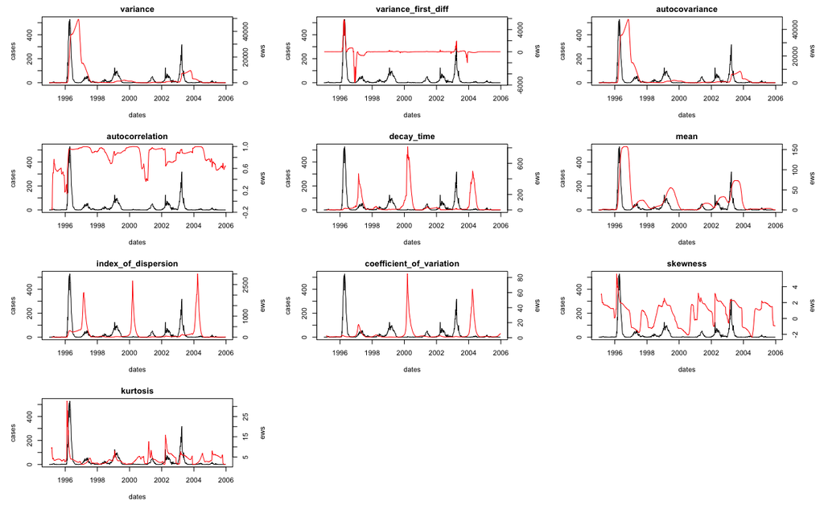

```r
do_region <- "Zinder (City)"
dates <- unique(measles_data$date)
par(mfrow = c(4,3))
for(do_ews in unique(all_stats$ews)){
  cases <- filter(measles_data, region == do_region) %>% pull(cases)
  ews <- filter(all_stats, region == do_region & ews == do_ews) %>% pull(value)
  plot_it(dates, cases, ews, lab = "ews", title = do_ews)
}
```

# Post-outbreak EWS

As the plots above show, most EWS get swamped out by the “memory” of outbreaks. To try and get around this, I am going to look at EWS after resetting them following outbreaks. I don’t think this is too contrived because real-world early detection systems would have to do the same thing.

## How to ID outbreaks

Following Toby’s suggestion, I am going to look at the distribution of outbreak sizes (i.e., cumulative cases in each year). I can then fit a mixture distribution of two weighted exponentials to the data, with one exponential explaining the large outbreaks and one the small outbreaks. This provides an objective way to define outbreaks for EWS detection.

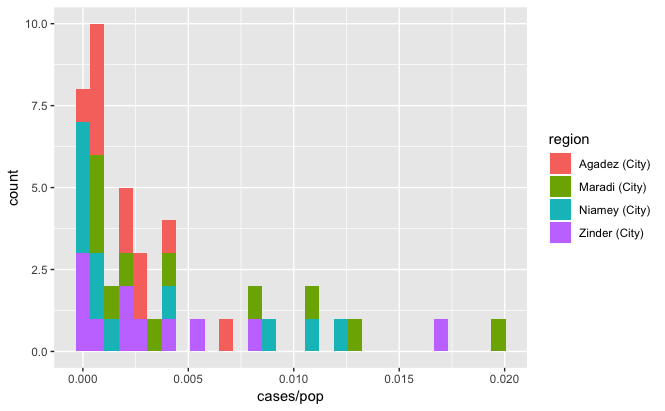

```r
pop_data <- tibble(
  region = c("Agadez (City)", "Maradi (City)", "Niamey (City)", "Zinder (City)"),
  pop = c(118224, 267249, 1027000, 322935)
)
cusum_data <- measles_data %>%
  group_by(region, year) %>%
  summarise(cases = sum(cases)) %>%
  left_join(pop_data)
ggplot(cusum_data, aes(x = cases/pop)) +
  geom_histogram(aes(fill = region))
```

```r
cusum_cases <- sort(cusum_data$cases / cusum_data$pop)
fit1 <- MASS::fitdistr(cusum_cases, "exponential")
x <- cusum_cases
mixexplik <- function(p,lambda1,lambda2) {
  z <- p*dexp(x,lambda1) + (1-p)*dexp(x,lambda2)
  return(-sum(log(z)))
}
mle_fit <- stats4::mle(minuslogl=mixexplik,
                       start= list(p=0.2,
                                   lambda1 = as.numeric(fit1$estimate),
                                   lambda2 = as.numeric(fit1$estimate)),
                       method="Nelder-Mead")
```

```
NaNs producedNaNs producedNaNs produced
```

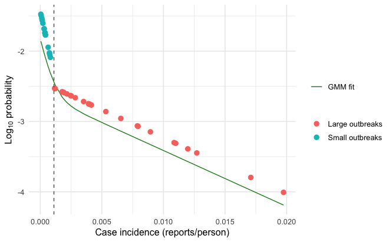

```r
get_prob <- function(x, rate1, rate2, p, x_scale, bin_width = 1){
  p1 <- pexp((x+bin_width)/x_scale, rate1) - pexp((x-bin_width)/x_scale, rate1)
  p2 <- pexp((x+bin_width)/x_scale, rate2) - pexp((x-bin_width)/x_scale, rate2)
  mixp <- p*p1+(1-p)*p2
  return(c(p1,p2,mixp))
}
x_scale <- 1e+05
xstar <- round(x*x_scale)
probs <- sapply(xstar, FUN = get_prob, rate1 = mle_fit@coef["lambda1"],
                rate2 = mle_fit@coef["lambda2"], p = mle_fit@coef["p"],
                x_scale = x_scale, bin_width = 1)
bound <- qexp(p = 0.5, rate = mle_fit@coef["p"]*mle_fit@coef["lambda1"])
probs_df <- t(log10(probs)) %>%
  as_tibble() %>%
  dplyr::rename(
    "log10prob_large" = V2,
    "log10prob_small" = V1,
    "log10prob_mix" = p
  ) %>%
  dplyr::mutate(
    incidence = x,
    outbreak_size = ifelse(incidence < bound, "small", "large"),
    plot_prob = ifelse(outbreak_size == "small", log10prob_small, log10prob_large)
  )
ggplot(probs_df, aes(x = incidence)) +
  geom_line(aes(y = log10prob_mix, color = "forestgreen")) +
  geom_point(aes(y = plot_prob, fill = outbreak_size), size = 3, shape = 21, color = "NA") +
  geom_vline(aes(xintercept = bound), linetype = 2, color = "grey35") +
  labs(x = "Case incidence (reports/person)",
       y = expression(paste(Log[10]," probability"))) +
  scale_fill_discrete(name = NULL, labels = c("Large outbreaks", "Small outbreaks")) +
  scale_color_manual(name = NULL, labels = "GMM fit", values = "forestgreen") +
  theme_minimal(base_size = 12)
```

OK, so now I can identify outbreak years in the untransformed (just cases) data for each city.

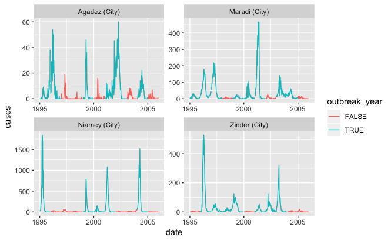

```r
outbreak_ids <- cusum_data %>%
  dplyr::mutate(
    incidence = cases/pop,
    outbreak_year = ifelse(incidence < bound, FALSE, TRUE)
  ) %>%
  dplyr::select(region, year, outbreak_year)
measles_data <- measles_data %>%
  left_join(outbreak_ids)
ggplot(measles_data, aes(x = date, y = cases, color = outbreak_year, group = year)) +
  geom_line() +
  facet_wrap(~region, scales = "free")
```

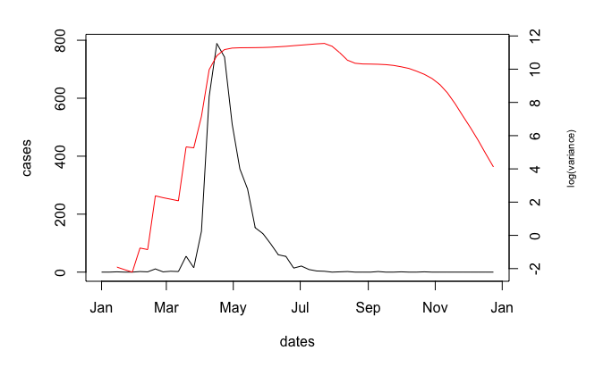

```r
niamey_test <- measles_data %>%
  filter(region == "Niamey (City)") %>%
  filter(year > 1998 & year < 2000)
cases <- niamey_test$cases
variance <- spaero::get_stats(
    x = cases,
    center_trend = "local_constant",
    center_kernel = "uniform",
    center_bandwidth = 16,
    stat_trend = "local_constant",
    stat_kernel = "uniform",
    stat_bandwidth = 16,
    lag = 1,
    backward_only = TRUE
  )$stats$variance
plot_it(dates = niamey_test$date, cases = cases, ews = log(variance), lab = "log(variance)", title = NULL)
```

```r
niamey_test <- measles_data %>%
  filter(region == "Maradi (City)")
out_vars <- tibble()
for(do_year in unique(niamey_test$year)){
  tmp_cases <- niamey_test %>%
    filter(year == do_year) %>%
    pull(cases)

  tmp_stats <- spaero::get_stats(
    x = tmp_cases,
    center_trend = "local_constant",
    center_kernel = "uniform",
    center_bandwidth = 16,
    stat_trend = "local_constant",
    stat_kernel = "uniform",
    stat_bandwidth = 16,
    lag = 1,
    backward_only = TRUE
  )$stats

  tmp_var <- tibble(
    year = do_year,
    date = filter(niamey_test, year == do_year)$date,
    variance = tmp_stats$variance,
    outbreak_year = filter(niamey_test, year == do_year)$outbreak_year
  )

  out_vars <- bind_rows(out_vars, tmp_var)
}
```

[output not shown]

```r
gam_data <- out_vars %>%
  dplyr::select(date, variance, outbreak_year) %>%
  dplyr::mutate(
    week_of_year = lubridate::week(date),
    log_variance = log(variance+0.00001),
    outbreak_year = as.factor(outbreak_year)
  ) %>%
  dplyr::select(-date)

test_formula <- as.formula(
  log_variance ~ outbreak_year + s(week_of_year, by = outbreak_year, k = 2)
)
gam_model <- mgcv::gam(formula = test_formula, data = gam_data)
```

```
basis dimension, k, increased to minimum possible
```

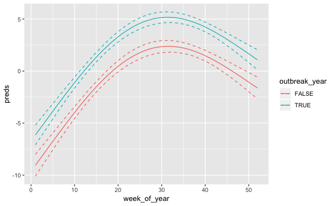

```r
pred_df <- tibble(
  week_of_year = rep(1:52, times = 2),
  outbreak_year = rep(as.factor(c(TRUE, FALSE)), each = 52)
)
preds <- predict(gam_model, newdata = pred_df, type = "response", se.fit = TRUE)
ests <- as.numeric(preds[[1]])
ses <- as.numeric(preds[[2]])
pred_df <- pred_df %>%
  mutate(preds = ests,
         se = ses)
ggplot(pred_df, aes(x = week_of_year, y = preds, color = outbreak_year)) +
  geom_line() +
  geom_line(aes(y = preds+(se*2)), linetype = 2) +
  geom_line(aes(y = preds-(se*2)), linetype = 2)
```

# But first, look at just case trajectories

[figure not shown]

```r
ggplot(niamey_test, aes(x = week_of_year, y = sqrt(cases), color = outbreak_year, group = year)) +
  geom_line()
```

# Extra

Maybe there is a variance value that serves as an indicator? Look at high AUCs from the simulations to see what the variances are.

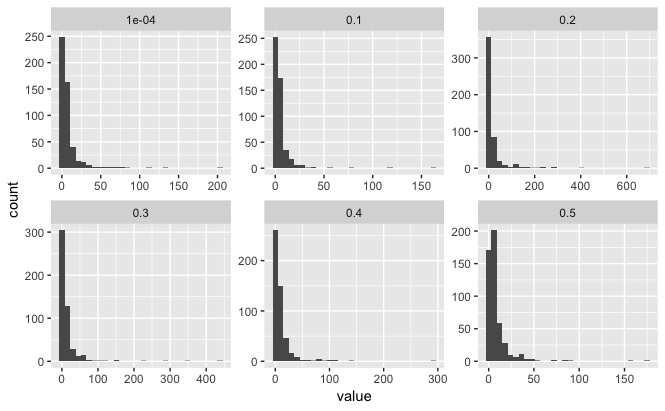

```r
ews <- read_csv("../../results/ews-emergence.csv") %>%
  filter(city == "Maradi" & metric == "variance" & half == "second")
ggplot(ews, aes(x = value)) +
  geom_histogram() +
  facet_wrap(~susc_discount, scales = "free")
```

```r
med_var <- ews %>%
  group_by(susc_discount) %>%
  summarise(value = median(value))
```